# Can You Improve Sentiment Polarity with LSTMs?

This project is designed to test your current knowledge on applying LSTMS to the [Cornell Movie Review dataset](http://www.cs.cornell.edu/people/pabo/movie-review-data/) provided by Cornell University. This dataset contains movie reviews introduced in [Pang & Lee (2004)](https://bit.ly/2SWGVBZ) with 2000 total observations. Detailed information about the data can be found [here](https://bit.ly/2N08o22).

Your goal is to develop and compare the performance of a word embedding deep learning classifier to one that incorporates LSTM sequence embedding. I will guide you along the way but this project expects you to do most of the work from importing and preprocessing text, to building the models.

Nearly all the code that you need can be found in these notebooks:

- [Intro to word embeddings](http://bit.ly/dl-imdb-embeddings)
- [Intro to LSTMs](http://bit.ly/dl-lstm-intro)

*Good luck!*

# Requirements

```r
library(keras)
library(tidyverse)
library(fs)
library(glue)
library(testthat)
```

# Import the data

For those in the workshop we have already downloaded the movie review data for you into the `"/materials/data/cornell_reviews"` directory. Outside of the workshop, you can find the download instructions [here](http://bit.ly/dl-rqmts).

```r
# get path to data
if (stringr::str_detect(here::here(), "conf-2020-user")) {
  movie_dir <- "/home/conf-2020-user/data/cornell_reviews/data"
} else {
  movie_dir <- here::here("materials", "data", "cornell_reviews", "data")
}

fs::dir_tree(movie_dir, recurse = FALSE)
```

```
/Users/b294776/Desktop/Workspace/Training/rstudio-conf-2020/dl-keras-tf/materials/data/cornell_reviews/data
├── neg
└── pos
```

**Step 1**: You can see the data have already been separated into positive vs negative sets. The actual reviews are contained in individual .txt files. Similar to [Intro to word embeddings](http://bit.ly/dl-imdb-embeddings), let’s go ahead use this structure to our advantage by iterating over each review and…

1. creating the path to each individual review file,
2. creating a label based on the “neg” or “pos” folder the review is in, and
3. saving the output as a data frame with each review on an individual row.

```r
training_files <- movie_dir %>%
  dir_ls() %>%
  map(dir_ls) %>%
  set_names(basename) %>%
  plyr::ldply(data_frame) %>%
  set_names(c("label", "path"))

# you should have 2000 total observations
expect_equal(nrow(training_files), 2000)
```

Go ahead and take a look at your data frame

```r
training_files
```

| label | path |
| --- | --- |
| neg | /Users/b294776/Desktop/Workspace/Training/rstudio-conf-2020/dl-keras-tf/materials/data/cornell_reviews/data/neg/cv000_29416.txt |
| neg | /Users/b294776/Desktop/Workspace/Training/rstudio-conf-2020/dl-keras-tf/materials/data/cornell_reviews/data/neg/cv001_19502.txt |
| neg | /Users/b294776/Desktop/Workspace/Training/rstudio-conf-2020/dl-keras-tf/materials/data/cornell_reviews/data/neg/cv002_17424.txt |
| neg | /Users/b294776/Desktop/Workspace/Training/rstudio-conf-2020/dl-keras-tf/materials/data/cornell_reviews/data/neg/cv003_12683.txt |
| neg | /Users/b294776/Desktop/Workspace/Training/rstudio-conf-2020/dl-keras-tf/materials/data/cornell_reviews/data/neg/cv004_12641.txt |
| neg | /Users/b294776/Desktop/Workspace/Training/rstudio-conf-2020/dl-keras-tf/materials/data/cornell_reviews/data/neg/cv005_29357.txt |
| neg | /Users/b294776/Desktop/Workspace/Training/rstudio-conf-2020/dl-keras-tf/materials/data/cornell_reviews/data/neg/cv006_17022.txt |
| neg | /Users/b294776/Desktop/Workspace/Training/rstudio-conf-2020/dl-keras-tf/materials/data/cornell_reviews/data/neg/cv007_4992.txt |
| neg | /Users/b294776/Desktop/Workspace/Training/rstudio-conf-2020/dl-keras-tf/materials/data/cornell_reviews/data/neg/cv008_29326.txt |
| neg | /Users/b294776/Desktop/Workspace/Training/rstudio-conf-2020/dl-keras-tf/materials/data/cornell_reviews/data/neg/cv009_29417.txt |

[output cut: 990 more lines]

**Step 2**: How many obseravations are in each response label (i.e. “neg” vs “pos”)?

```r
count(training_files, label)
```

| label | n |
| --- | --- |
| neg | 1000 |
| pos | 1000 |

**Step 3**: Next, let’s iterate over each row and

1. save the label in a labels vector,
2. import the movie review, and
3. save in a texts vector.

```r
obs <- nrow(training_files)
labels <- vector(mode = "integer", length = obs)
texts <- vector(mode = "character", length = obs)

for (file in seq_len(obs)) {
  label <- training_files[[file, "label"]]
  path <- training_files[[file, "path"]]

  labels[file] <- ifelse(label == "neg", 0, 1)
  texts[file] <- readChar(path, nchars = file.size(path))
}
```

The number of observations in your text should be equal to the number of responses.

```r
expect_equal(length(texts), length(labels))
```

Go ahead and check out the text of a couple reviews.

```r
texts[1]
```

```
[1] "plot : two teen couples go to a church party , drink and then drive . \nthey get into an accident . \none of the guys dies , but his girlfriend continues to see him in her life , and has nightmares . \nwhat's the deal ? \nwatch the movie and \" sorta \" find out . . . \ncritique : a mind-fuck m…
```

# Data exploration

**Step 4**: Before preprocessing, let’s get a sense of two attributes that will help us set two of our preprocessing hyperparameters:

1. How many unique words exist across all our reviews? We’ll use this to determine a good starting point for preprocessing our text.
2. What is the distribution of word count across all movie reviews (i.e. mean, median)? We’ll use this to determine a good starting point for preprocessing our text.

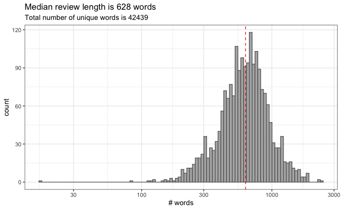

```r
text_df <- texts %>%
  tibble(.name_repair = ~ "text") %>%
  mutate(text_length = str_count(text, "\\w+"))

unique_words <- text_df %>%
  tidytext::unnest_tokens(word, text) %>%
  pull(word) %>%
  n_distinct()

avg_review_length <- median(text_df$text_length, na.rm = TRUE)

ggplot(text_df, aes(text_length)) +
  geom_histogram(bins = 100, fill = "grey70", color = "grey40") +
  geom_vline(xintercept = avg_review_length, color = "red", lty = "dashed") +
  scale_x_log10("# words") +
  ggtitle(glue("Median review length is {avg_review_length} words"),
          subtitle = glue("Total number of unique words is {unique_words}"))
```

# Data preprocessing

**Step 5**: Now let’s tokenize our text sequences. To do so we:

1. Specify how many words we want to include. Remember, a good starting point to use roughly 50% of the number of unique words in the data. This is a hyper- parameter that you can always come back to and adjust.
2. Create a `text_tokenizer` object which defines how we want to preprocess the text. The defaults are sufficient.
3. Apply the tokenizer to our text with `fit_text_tokenizer()`.
4. Extract our vectorized review data with `texts_to_sequences()`.

```r
# 1
top_n_words <- 20000

# 2-3
tokenizer <- text_tokenizer(num_words = top_n_words) %>%
  fit_text_tokenizer(texts)

# 4
sequences <- texts_to_sequences(tokenizer, texts)
```

Go ahead and check out the first vectorized sequence. Should look familiar from earlier modules.

```r
# The vectorized first instance:
sequences[[1]]
```

```
  [1]    97    76   948  4621   130     5     2  2015   788  3763     3   102  1313
 [14]    36    72    55    24  1340    23     4     1   518  1324    16    13   677
 [27]  1570     5    83    54     7    33    89     3    32  4476   603     1   637
 [40]   241     1    26     3  8853   189    40  2185     2   301  6461    26    12
 [53]     1   948  1457     8  2401    19     2    79   690   361    16  1767     9
 [66]     7     2    79   105  3979    45     6    48   142    14   465    24    56
 [79]  3667    23     5  1174   194    18  1341  8854    95    45   526     5   830
 [92]     1  7097   902    11   169   362     3   117   341  4203  8855    16    52
[105]    20    61     3   105   752     4   242    35  2694     4    95     3   112
[118]  1878    50   248    14    23  6179    36   249     5    31   624    14   271
[131]  3764  1223    16  2794     9  2283    39    48    20     1   469    11     1
[144]    26    77    64   348   353     6     8    37   321    88  7839     9   436
[157]    87  1314    16   102    55    14  1445   145     7    45    34    10    24
[170]   161  1122    31    59   361   603   159    19    52    20  1076    52    20
[183]    81   504   135    28     1   328    52    20   485    27   177    38     1
```

[output cut: 40 more lines]

We can see how our tokenizer converted our original text to a cleaned up version:

```r
cat(crayon::blue("Original text:\n"))
```

```
Original text:
```

```r
texts[[1]]
```

```
[1] "plot : two teen couples go to a church party , drink and then drive . \nthey get into an accident . \none of the guys dies , but his girlfriend continues to see him in her life , and has nightmares . \nwhat's the deal ? \nwatch the movie and \" sorta \" find out . . . \ncritique : a mind-fuck m…
```

```r
cat(crayon::blue("\nRevised text:\n"))
```

```
Revised text:
```

```r
paste(unlist(tokenizer$index_word)[sequences[[1]]] , collapse = " ")
```

```
[1] "plot two teen couples go to a church party drink and then drive they get into an accident one of the guys dies but his girlfriend continues to see him in her life and has nightmares what's the deal watch the movie and sorta find out critique a mind fuck movie for the teen generation that touche…
```

**Step 6**: Next, since each review is a different length, we need to limit ourselves to a certain number of words so that all our text sequences are the same length.

To do so we:

1. Specify the max length for each sequence. You can start out with 500 and then tune this hyperparameter later.
2. Use `pad_sequences()` to truncate or pad reviews to the specified `max_len`.

```r
max_len <- 500
features <- pad_sequences(sequences, maxlen = max_len)
```

Your now have your preprocessed feature data that is a 2D tensor (aka matrix) and contains 2000 observations (rows) and `max_len` columns.

```r
dim(features)
```

```
[1] 2000  500
```

```r
expect_equal(class(features), "matrix")
expect_equal(dim(features), c(obs, max_len))
```

You can see how the final preprocessed sequence looks for the first movie review with the following code:

```r
paste(unlist(tokenizer$index_word)[features[1,]], collapse = " ")
```

```
[1] "a of chase scenes there are tons of weird things that happen and most of it is simply not explained now i personally don't mind trying to unravel a film every now and then but when all it does is give me the same clue over and over again i get kind of fed up after a while which is this film's b…
```

# Model training

**Step 7**: To train our model we will use the `validation_split` procedure within `fit()`. Remember, this takes the last XX% of our data to be used as our validation set. But if you recall, our data was organized in “neg” and “pos” folders so we should randomize our data to make sure our validation set doesn’t end up being all positive or negative reviews!

```r
set.seed(123)
index <- sample(1:nrow(features))

x_train <- features[index, ]
y_train <- labels[index]

# there should be 2 unique values (0 - neg, 1 - pos) in last 30% of data
expect_equal(
  length(unique(y_train[floor(length(y_train) * 0.7):length(y_train)])),
  2
  )
```

## Word embedding model

**Step 8**: We’re now ready to do modeling. For our first model, let’s create a model that:

1. applies a word embedding layer
   - `input_dim` should equal `top_n_words`
   - `input_length` should equal `max_len`
   - start with `output_dim` = 16
2. flattens the embeddings
3. classifies with a dense layer

You can use early stopping if you’d like but for the first model:

- use the default learning rate
- 20 epochs is more than enough
- use a batch size of 32
- use a validation split of 30%

```r
model_basic <- keras_model_sequential() %>%
  layer_embedding(
    input_dim = top_n_words,  # number of words we are considering
    input_length = max_len,   # length that we have set each review to
    output_dim = 16           # length of our word embeddings
    ) %>%
  layer_flatten() %>%
  layer_dense(units = 1, activation = "sigmoid")

model_basic %>% compile(
  optimizer = "rmsprop",
  loss = "binary_crossentropy",
  metrics = "accuracy"
)

history_basic <- model_basic %>%
  fit(
    x_train, y_train,
    epochs = 20,
    batch_size = 32,
    validation_split = 0.3,
    callbacks = list(
      callback_early_stopping(patience = 3, restore_best_weights = TRUE)
      )
    )
```

Run the following code to check out your optimal loss and corresponding accuracy.

```r
best_epoch <- which.min(history_basic$metrics$val_loss)
best_loss <- history_basic$metrics$val_loss[best_epoch] %>% round(3)
best_acc <- history_basic$metrics$val_accuracy[best_epoch] %>% round(3)

glue("Our optimal loss is {best_loss} with an accuracy of {best_acc}")
```

```
Our optimal loss is 0.565 with an accuracy of 0.705
```

## Word embedding + LSTM model

**Step 9**: Now let’s build on to the previous model by adding an LSTM layer after the `layer_embedding` layer. When feeding an embedding layer into an LSTM layer you **do not** need to flatten the layer. Reference the [Intro to LSTMs notebook](http://bit.ly/dl-lstm-intro#train-an-lstm). For this first LSTM model use `units = 32`.

```r
model_lstm <- keras_model_sequential() %>%
  layer_embedding(
    input_dim = top_n_words,  # number of words we are considering
    input_length = max_len,   # length that we have set each review to
    output_dim = 16            # length of our word embeddings
    ) %>%
  layer_lstm(units = 32) %>%
  layer_dense(units = 1, activation = "sigmoid")

model_lstm %>% compile(
  optimizer = "rmsprop",
  loss = "binary_crossentropy",
  metrics = "accuracy"
)

history_lstm <- model_lstm %>% fit(
  x_train, y_train,
  epochs = 20,
  batch_size = 32,
  validation_split = 0.3,
  callbacks = list(
    callback_early_stopping(patience = 3, restore_best_weights = TRUE)
    )
)
```

Run the following code to check out your optimal loss and corresponding accuracy.

1. How does it compare to the word embedding only model?
2. Why do you think there is a difference?

```r
best_epoch <- which.min(history_lstm$metrics$val_loss)
best_loss <- history_lstm$metrics$val_loss[best_epoch] %>% round(3)
best_acc <- history_lstm$metrics$val_accuracy[best_epoch] %>% round(3)

glue("Our optimal loss is {best_loss} with an accuracy of {best_acc}")
```

```
Our optimal loss is 0.445 with an accuracy of 0.795
```

## Search for a better model

**Step 10**: Spend the rest of the time tuning hyperparameters and see if you can find a better model. Things you can try:

- Preprocessing hyperparameters
  - adjust the number of words to retain in the word index (`top_n_words`)
  - adjust the size of the sequences (`max_len`)
- Word embedding layer
  - adjust the `output_dim`
- LSTM layer
  - adjust the number of `units`
  - add dropout (ref http://bit.ly/dl-lstm-intro#your-turn-5min-1)
  - maybe even add a 2nd LSTM layer
- Other
  - adjust the learning rate (or even the optimizer (i.e. try “adam”))
  - adjust the `batch_size`
  - add a callback to adjust the learning upon plateauing

[🏠](https://github.com/rstudio-conf-2020/dl-keras-tf)